# Determining Space-Time model form and Bayesian Model Avergaing (BMA) with `stgam`

Lex Comber, Paul Harris and Chrs Brunsdon

June 2024

## Overview

```r
stvc.gam = gam(privC ~ 0 +
                 Intercept   + s(X, Y, year, bs = 'gp', by = Intercept) +
                 unemp + s(X, Y, year, bs = "gp", by = unemp) +
                 pubC  + s(X, Y, year, bs = "gp", by = pubC),
               data = productivity)
```

The `stvc.gam` model above is specified in a way that assumes the presence of some spatio-temporal dependencies (or interactions) between the target and the predictor variables. However this assumption may be incorrect and the model may be incorrectly specified.

This vignette

- Reflects on the assumptions associated with different model forms or specifications.
- Constructs different varying coefficient models and evaluates them using BIC.
- Constructs probabilities to determine the best model or best set of competing models.
- Undertakes Bayesian Model Averaging to combine the highly probable models.

The code below loads the packages and data:

```r
# load the packages
library(stgam)
library(cols4all)   # for nice shading in graphs and maps
library(cowplot)    # for managing plots
library(dplyr)      # for data manipulation
library(ggplot2)    # for plotting and mapping
library(glue)       # for model construction
library(mgcv)       # for GAMs
library(sf)         # for spatial data
library(doParallel) # for parallelising operations
library(purrr)      # for model construction
library(tidyr)      # for model construction
# load the data
data(productivity)
data(us_data)
```

## Considering model form

How should you specify your varying coefficient model?

The STCV model specified above included space and time in a single smooth (spline) for each the covariates. This is to assume that that spatial and temporal processes *do* interact and that the *temporal trends* in predictor-target variable relationships will *vary with location*. But is this assumption correct? If you have a specific a hypothesis that you are testing or working under a particular theory related to how space and time interact in the process you are examining, then you can simply specify how the covariates interact with target variable. However, more commonly we are seeking inference (understanding) about *how* processes interact in space and time.

In this vignette, these interactions are explored using a data driven (rather than theoretical) approach. A series of different models are created, each with different assumptions, and they are evaluated to determine which one of them is, or which set of them are, the most probable.

Multiple models can be created to explore all possible combinations of interaction and then to select the best model, through a probability based measure like BIC (see Comber et al. (submitted) for a full treatment of this). There are a total 6 possible way that each covariate could be specified in the model:

1. It is omitted.
2. It is included as a parametric response with no spline.
3. It is included in a spline with location.
4. It is included a spline with time.
5. It is included in a single spline with location and time.
6. It is included in 2 separate splines with location and time.

The intercept can be treated similarly, but without it being absent (i.e. 5 options).

To investigate STVC model form, a series of models can be specified, with each combination of the 6 permutations for each covariate, plus 5 states for the intercept. The best model(s) can be determined by quantifying the likelihood (probability) of each of model being the correct model. This can be approximated using the Bayesian Information Criterion (BIC) (Schwarz 1978) as described in full in Comber et al. (submitted), and if the probabilities for multiple models are high, then the models can be combined using a Bayesian Model Averaging (BMA) approach. BMA is described in the context of spatial modelling in Fragoso, Bertoli, and Louzada (2018) and summarised in Brunsdon, Harris, and Comber (2023), but in brief, if a number of competing models exist with at least one quantity of interest that all have in common, and the likelihoods of each of them being the correct model is known (e.g. from BIC ), then a posterior distribution of the quantity of interest can be obtained by averaging them using the likelihoods as weights. In this way it allows competing models, treating space and time in different ways, to be combined.

## Creating multiple models: a walk-through

To create STVC multiple models, the code below first defines a grid of numbers for each covariate form. This is passed to a function to create the formula specifying each model, with different terms and smooths, which in turn is passed to the `gam` function.

```r
# define intercept term
productivity <- productivity |> mutate(Intercept = 1)
# define grid of combinations (nrow = 180)
terms_gr = expand.grid(intcp = 1:5, unemp = 1:6, pubC = 1:6)
# examine a random slice
terms_gr |> slice_sample(n = 6)
```

```
#>   intcp unemp pubC
#> 1     1     3    3
#> 2     1     1    5
#> 3     3     5    6
#> 4     4     4    2
#> 5     5     5    3
#> 6     4     4    5
```

A function is defined to create the equations: here this is bespoke to the covariate names and number in the `productvity` data:

```r
# define a function to make the equations
makeform_prod <- function(intcp, unemp, pubC, bs='gp') {
  #coords <-    c("X,Y",    "X2,Y2")[coords]
  intx <- c("",
            glue("+s(year,bs='{bs}',by=Intercept)"),
            glue("+s(X,Y,bs='{bs}',by=Intercept)"),
            glue("+s(X,Y,bs='{bs}',by=Intercept) + s(year,bs='{bs}',by=Intercept)"),
            glue("+s(X,Y,year,bs='{bs}',by=Intercept)"))[intcp]
  unempx <- c("",
              "+ unemp",
              glue("+s(year,bs='{bs}',by=unemp)"),
              glue("+s(X,Y,bs='{bs}',by=unemp)"),
              glue("+s(X,Y,bs='{bs}',by=unemp) + s(year,bs='{bs}',by=unemp)"),
              glue("+s(X,Y,year,bs='{bs}',by=unemp)"))[unemp]
  pubCx <- c("",
             "+ pubC",
             glue("+s(year,bs='{bs}',by=pubC)"),
             glue("+s(X,Y,bs='{bs}',by=pubC)"),
             glue("+s(X,Y,bs='{bs}',by=pubC) + s(year,bs='{bs}',by=pubC)"),
             glue("+s(X,Y,year,bs='{bs}',by=pubC)"))[pubC]
  return(formula(glue("privC~Intercept-1{unempx}{intx}{pubCx}")))
}
```

To see how this works, the code below passes some numbers to it.

```r
makeform_prod(intcp = 5, unemp = 2, pubC = 4, bs='gp')
```

```
#> privC ~ Intercept - 1 + unemp + s(X, Y, year, bs = "gp", by = Intercept) +
#>     s(X, Y, bs = "gp", by = pubC)
#> <environment: 0x7faf97c6cc38>
```

Next a function to undertake the analysis and record the BIC, return the indices and the formula is defined. Not that this has the `terms_gr` object defined above embedded in it, taking just an index of the grid row number as input:

```r
do_gam = function(i){
    f <- makeform_prod(intcp = terms_gr$intcp[i],
                     unemp = terms_gr$unemp[i],
                     pubC = terms_gr$pubC[i],
                     bs='gp')
    m = gam(f,data=productivity)
    bic = BIC(m)
    index = data.frame(intcp = terms_gr$intcp[i],
                       unemp = terms_gr$unemp[i],
                       pubC = terms_gr$pubC[i])
    f = paste0('privC~', as.character(f)[3] )
    return(data.frame(index, bic, f))
    #return(bic)
}
```

This can be tested:

```r
terms_gr[100,]
do_gam(100)
```

Finally, this can be put in a loop to evaluate all of the potential space-time models:

```r
t1 = Sys.time()
res_gam <- NULL
for(i in 1:nrow(terms_gr)) {
  res.i = do_gam(i)
  res_gam = rbind(res_gam, res.i)
}
Sys.time() - t1
```

```
#> Time difference of 2.520804 mins
```

For more complex problems, you could parallelise the loop if you have a large multivariate analyses. The output is the same as the `for` loop above, it is just created more quickly.

```r
# set up the parallelisation
library(doParallel)
cl <- makeCluster(detectCores()-1)
registerDoParallel(cl)
# do the parallel loop
t1 = Sys.time()
res_gam <-
  foreach(i = 1:nrow(terms_gr),
          .combine = 'rbind',
          .packages = c("glue", "mgcv", "purrr")) %dopar% {
            do_gam(i)
            }
Sys.time() - t1
# release the cores
stopCluster(cl)
# have a look
head(res_gam)
```

## Evaluating multiple models: a walk-through

Having generated STVC multiple models and recorded the BIC values for them, it is possible to generate probabilities for each model and evaluate them. The logics and supporting equations for this evaluations of each mode are detailed in Comber et al. (submitted). The results need to be sorted, the best 10 models identified, their structures extracted and then their relative probabilities calculated:

```r
# sort the results
mod_comp <- tibble(
    res_gam) |>
    rename(BIC = bic) |>
    arrange(BIC)
# transpose the indices to to model terms
# rank and return the top 10 results
int_terms <- \(x) c("Fixed","s_T", "s_S", "s_T + S_S", "s_ST")[x]
var_terms <- \(x) c("---", "Fixed","s_T", "s_S", "s_T + s_S", "s_ST")[x]
mod_comp_tab <-
  mod_comp |>
  slice_head(n = 10) |>
  mutate(across(unemp:pubC,var_terms)) |>
  mutate(intcp = int_terms(intcp)) |>
  rename(`Intercept` = intcp,
         `Unemployment.` = unemp,
         `Public Captial` = pubC) |>
  mutate(Rank = 1:n()) |>
  relocate(Rank) |>
  select(-f)
# determine the relative probabilities
# ie relative to the top ranked model
p1_vec = NULL
for(i in 2:10) {
  p1 = exp(-(mod_comp_tab$BIC[i]-mod_comp_tab$BIC[1])/2)
  p1 = p1/(1+p1)
  p1_vec = c(p1_vec, p1)
}
mod_comp_tab$`Pr(M)` = c("--", paste0(format(round(p1_vec*100, digits=1), nsmall = 1), "%"))
```

The results can be examined:

```r
mod_comp_tab
```

```
#> # A tibble: 10 × 6
#>     Rank Intercept Unemployment. `Public Captial`    BIC `Pr(M)`
#>    <int> <chr>     <chr>         <chr>             <dbl> <chr>
#>  1     1 s_ST      ---           s_ST             17821. "--"
#>  2     2 s_T + S_S ---           s_ST             17821. "50.0%"
#>  3     3 s_S       ---           s_ST             17821. "50.0%"
#>  4     4 s_ST      Fixed         s_ST             17821. "50.0%"
#>  5     5 s_T + S_S Fixed         s_ST             17821. "50.0%"
#>  6     6 s_S       Fixed         s_ST             17821. "50.0%"
#>  7     7 s_ST      s_T           s_ST             17821. "49.9%"
#>  8     8 s_T + S_S s_T           s_ST             17821. "49.4%"
#>  9     9 s_S       s_T           s_ST             17821. "49.4%"
#> 10    10 s_T       s_T + s_S     s_ST             17831. " 0.4%"
```

The results are sorted and suggest that nine of the models are highly probable, each with probabilities of better than the best ranked model of >10%. These are candidates for Bayesian Model Averaging. The are some commonalities in the specification of the 9 models:

- It does not matter whether the Intercept varies over space or time or together either interdependently or simultaneously;
- Unemployment can be absent, fixed or in a temporal smooth.
- Public Capital interacts simultaneously over space and time.

## Creating and Evaluating multiple models using `stgam` functions

The process above had a number of stages: - a grid was defined with indices for each variable defining how it is specified in each model - this was used to create formula specifying each variable in different ways - each model was constructed and the BIC calculated using a `for` loop or a parallelised approach - the probability for each model was determined and the top 10 models returned

The `stgam` package has generic function that wrap these operations and the code below applies them to the STVC problem. The `evaluate_models` function creates and evaluates the different models (it may take a minute or so to run):

```r
stvc_res_gam = evaluate_models(input_data = productivity,
                               target_var = "privC",
                               covariates = c("unemp", "pubC"),
                               coords_x = "X",
                               coords_y = "Y",
                               STVC = TRUE,
                               time_var = "year")
```

The results can be compared with the `res_gam` object created earlier:

```r
head(res_gam)
head(stvc_res_gam)
```

The model probabilities can be extracted using the `gam_model_probs` function, here again suggesting that nine space time models are equally as probable:

```r
stvc_mods = gam_model_probs(stvc_res_gam, n = 10)
stvc_mods
```

```
#> # A tibble: 10 × 7
#>     Rank Intercept unemp     pubC     BIC f                                        `Pr(M)`
#>    <int> <chr>     <chr>     <chr>  <dbl> <chr>                                    <chr>
#>  1     1 s_ST      s_T       s_ST  17821. "privC ~ Intercept - 1 + s(X, Y, year, … --
#>  2     2 s_T + S_S s_T       s_ST  17821. "privC ~ Intercept - 1 + s(X, Y, bs = \… 0.500
#>  3     3 s_S       s_T       s_ST  17821. "privC ~ Intercept - 1 + s(X, Y, bs = \… 0.500
#>  4     4 s_ST      ---       s_ST  17821. "privC ~ Intercept - 1 + s(X, Y, year, … 0.500
#>  5     5 s_T + S_S ---       s_ST  17821. "privC ~ Intercept - 1 + s(X, Y, bs = \… 0.500
#>  6     6 s_S       ---       s_ST  17821. "privC ~ Intercept - 1 + s(X, Y, bs = \… 0.500
#>  7     7 s_ST      Fixed     s_ST  17821. "privC ~ Intercept - 1 + s(X, Y, year, … 0.500
#>  8     8 s_T + S_S Fixed     s_ST  17821. "privC ~ Intercept - 1 + s(X, Y, bs = \… 0.500
#>  9     9 s_S       Fixed     s_ST  17821. "privC ~ Intercept - 1 + s(X, Y, bs = \… 0.500
#> 10    10 s_T       s_T + s_S s_ST  17831. "privC ~ Intercept - 1 + s(year, bs = \… 0.004
```

Of particular interest are the forms of the covariates in in each high ranking model:

- The Intercept is variously in a spatial, temporal, spatial plus temporal or space-time smooth.
- Unemployment is either absent, fixed or in a temporal smooth.
- Public capital (`pubC`) is always specified with a space-time smooth.

We should expect to see these trends when the models are averaged. Note, also the function has here calculated the *relative probabilities* for the STVC models because the individual BIC values resulted in probabilities that were too close to zero to be machine encodable.

The functions can be applied to a SVC problem:

```r
svc_res_gam = evaluate_models(input_data = productivity |> filter(year == "1970"),
                              target_var = "privC",
                              covariates = c("unemp", "pubC"),
                              coords_x = "X",
                              coords_y = "Y",
                              STVC = FALSE,
                              time_var = NULL)
# head(svc_res_gam)
svc_mods = gam_model_probs(svc_res_gam, n = 10)
svc_mods
```

```
#> # A tibble: 10 × 7
#>     Rank Intercept unemp pubC    BIC f                                           `Pr(M|D)`
#>    <int> <chr>     <chr> <chr> <dbl> <chr>                                           <dbl>
#>  1     1 Fixed     Fixed s_S   1060. "privC ~ Intercept - 1 + unemp + s(X, Y, b…     0.314
#>  2     2 Fixed     ---   s_S   1060. "privC ~ Intercept - 1 + s(X, Y, bs = \"gp…     0.314
#>  3     3 s_S       Fixed s_S   1062. "privC ~ Intercept - 1 + s(X, Y, bs = \"gp…     0.125
#>  4     4 s_S       ---   s_S   1062. "privC ~ Intercept - 1 + s(X, Y, bs = \"gp…     0.124
#>  5     5 Fixed     s_S   s_S   1062. "privC ~ Intercept - 1 + s(X, Y, bs = \"gp…     0.12
#>  6     6 s_S       s_S   s_S   1069. "privC ~ Intercept - 1 + s(X, Y, bs = \"gp…     0.004
#>  7     7 s_S       ---   Fixed 1108. "privC ~ Intercept - 1 + s(X, Y, bs = \"gp…     0
#>  8     8 Fixed     ---   Fixed 1109. "privC ~ Intercept - 1 + pubC"                  0
#>  9     9 Fixed     s_S   Fixed 1110. "privC ~ Intercept - 1 + s(X, Y, bs = \"gp…     0
#> 10    10 s_S       Fixed Fixed 1111. "privC ~ Intercept - 1 + s(X, Y, bs = \"gp…     0
```

If only one model was highly probable, then this could be specified. The code below does this for the top SVC model:

```r
productivity <- productivity |> mutate(Intercept = 1)
f = as.formula(svc_mods$f[1])
svc.gam = gam(f, data = productivity |> filter(year == "1970"))
summary(svc.gam)
```

## Combining multiple models using Bayesian Model Averaging

For both the SVC and STVC cases, a number of models were highly probable. It is possible to combine these models using the probabilities as weights combine (average) the coefficient estimates, under a Bayesian Model Averaging approach (see Comber et al. (submitted) for details). The code below applies the `do_bma` function to the summary tables generated above. The code can be used to construct the BMA coefficients from absolute or relative probabilities.

```r
# SVC with absolute probabilities
svc_bma <- do_bma(model_table = svc_mods,
                  terms = c("Intercept", "unemp", "pubC"),
                  thresh = 0.1,
                  relative = FALSE,
                  input_data = productivity |> filter(year == "1970"))
# STVC with relative probabilities
stvc_bma <- do_bma(model_table = stvc_mods,
                  terms = c("Intercept", "unemp", "pubC"),
                  thresh = 0.1,
                  relative = TRUE,
                  input_data = productivity)
```

The results can be joined back to the spatial layer, in this case `us_data` to be mapped:

```r
# join
svc_bma_sf <-
  us_data |> select(GEOID) |>
  left_join(productivity |>
              filter(year == "1970") |> select(GEOID, year) |>
              cbind(svc_bma)) |>
  relocate(geometry, .after = last_col())
```

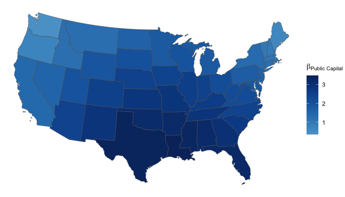

The spatial variation of the Public captial generated using a Bayesian Model Avaergaing approach.

```r
#  map
tit =expression(paste(""*beta[`Public Capital`]*" "))
ggplot(data = svc_bma_sf, aes(fill=pubC)) +
  geom_sf() +
  scale_fill_continuous_c4a_div(palette="brewer.blues",name=tit) +
  coord_sf() +
  theme_void()
```

The variations in the averaged BMA STVC coefficient estimates can be mapped in a similar way by linking to the `us_data` spatial layer, and here we see the nature of the temporal variation in the Unemployment and spatio-temporal variation in Public capital covariates as expected.

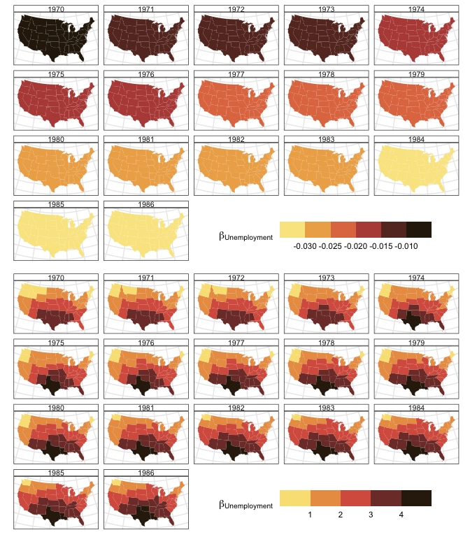

The spatial variation of coefficient estimatess for BMA Unemployment and Public captial over time, generated Bayesian Model Avaergaing approach.

```r
# link the data
stvc_bma_sf <-
  us_data |> select(GEOID) |>
  left_join(productivity |>
              select(GEOID, year) |>
              cbind(stvc_bma)) |>
  relocate(geometry, .after = last_col())

# create the plots
tit =expression(paste(""*beta[`Unemployment`]*""))
p1 = stvc_bma_sf |>
  ggplot() + geom_sf(aes(fill = unemp), col = NA) +
    scale_fill_binned_c4a_seq(palette="scico.lajolla", name = tit) +
  facet_wrap(~year) +
    theme_bw() + xlab("") + ylab("") +
    theme(
      strip.background =element_rect(fill="white"),
      strip.text = element_text(size = 8, margin = margin()),
      legend.position = c(.7, .1),
      legend.direction = "horizontal",
      legend.key.width = unit(1.15, "cm"),
        axis.title.x=element_blank(),
        axis.text.x=element_blank(),
        axis.ticks.x=element_blank(),
        axis.title.y=element_blank(),
        axis.text.y=element_blank(),
        axis.ticks.y=element_blank())
p2 = stvc_bma_sf |>
  ggplot() + geom_sf(aes(fill = pubC), col = NA) +
    scale_fill_binned_c4a_seq(palette="scico.lajolla", name = tit) +
  facet_wrap(~year) +
    theme_bw() + xlab("") + ylab("") +
    theme(
      strip.background =element_rect(fill="white"),
      strip.text = element_text(size = 8, margin = margin()),
      legend.position = c(.7, .1),
      legend.direction = "horizontal",
      legend.key.width = unit(1.15, "cm"),
        axis.title.x=element_blank(),
        axis.text.x=element_blank(),
        axis.ticks.x=element_blank(),
        axis.title.y=element_blank(),
        axis.text.y=element_blank(),
        axis.ticks.y=element_blank())
plot_grid(p1, p2, nrow = 2)
```

## Summary

The key and substantive methodological point in this vignette is the need to consider the nature of the spatial and temporal interactions (dependencies) between the target and predictor variables.

Model form (and thus the nature of the space-time process) should not be assumed and hence the provision of functions to create , evaluate and rank multiple models in the `stgam` package. Most approaches to SVC and STVC modelling implicitly assume specific spatial and space-time dependencies.

The approach presented din this vignettes represents a fundamental difference in philosophy to (spatial and) space-time modelling. The method is essentially about model comparison to *test* for space time dependency.

# References

Brunsdon, Chris, Paul Harris, and Alexis Comber. 2023. *Smarter Than Your Average Model? Bayesian Model Averaging as a Spatial Analysis Tool*. 12th International Conference on Geographic Information Science.

Comber, Alexis, Paul Harris, Naru Tsutsumida, Jennie Gray, and Chris Brunsdon. submitted. “Where, When and How? Specifying Spatially and Temporally Varying Coefficient Models Using Generalized Additive Models with Gaussian Process Splines.” *International Journal of Geographical Information Science*, submitted.

Fragoso, Tiago M, Wesley Bertoli, and Francisco Louzada. 2018. “Bayesian Model Averaging: A Systematic Review and Conceptual Classification.” *International Statistical Review* 86 (1): 1–28.

Schwarz, Gideon. 1978. “Estimating the Dimension of a Model.” *The Annals of Statistics*, 461–64.